# Wasa Triathlon EDA App

2019-03-04

## Wasa Triathlon EDA App.

In its promotional campaign, the race is described as: “Gerick Sports Wasa Lake Triathlon features elite prize money and attracts some of the fastest triathletes in the West. Age groupers and elites compete together on a scenic and fast course.” Wasa Lake is located in the beautiful province of British Columbia just west from the Rocky Mountains and 4 hours away from Calgary.

## Use of the App

To check the reulst you have two tab option: Overall results and by Categories.

After Selection you will have the option to filter the results by gender and year. You can select multiple years to compare

## Results

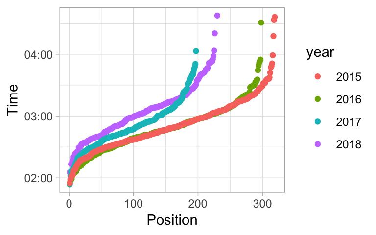

```r
  ggplot(data = wasaData, aes(x= Position, y = Time, color=year))+
            geom_point()+
            theme_light()
```

## Results

Another useful information is to be able to compare the time for each cactegory in each sport. In tab "Categories" we can compare between all the variable.

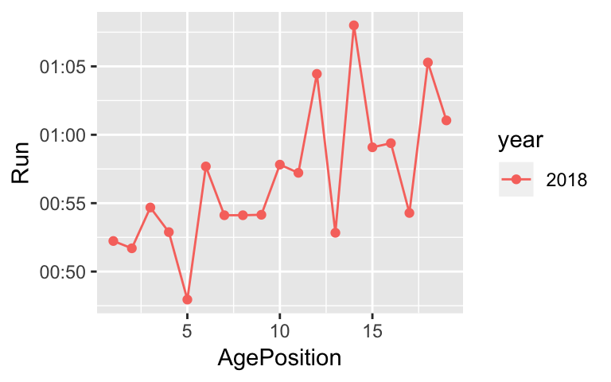

```r
            ggplot(data = wasaDataF, aes( y = Run, x=AgePosition,color =year))+
              geom_line()+
              geom_point()
```